# Anàlisi textual

## Preprocessament

Per poder desenvolupar l’anàlisi textual primer cal preprocessar la base de dades amb l’objectiu de mantenir només aquella informació rellevant que permeti una anàlisi més precisa.

Aquest preprocessament inclou eliminar els espais en blanc, les majúscules, els signes de puntuació, els números, altres caràcters especials, les stop words (to, the, a…), etc. A més, s’aplica el procés de lematització de les paraules (transformar les paraules a la seva arrel per poder trobar més relacions entre textos diferents).

S’agafen les paraules que surten 5 vegades o més per tenir aquella informació rellevant i les representem gràficament:

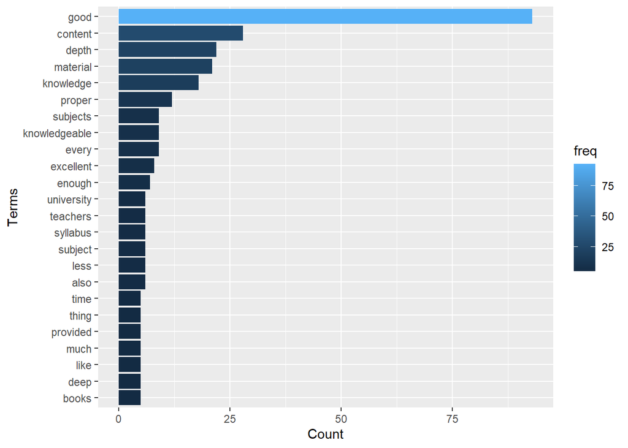

[interactive chart not shown]

## Topic modeling

### Per dos tòpics

Dividint les respostes dels alumnes en dos temes:

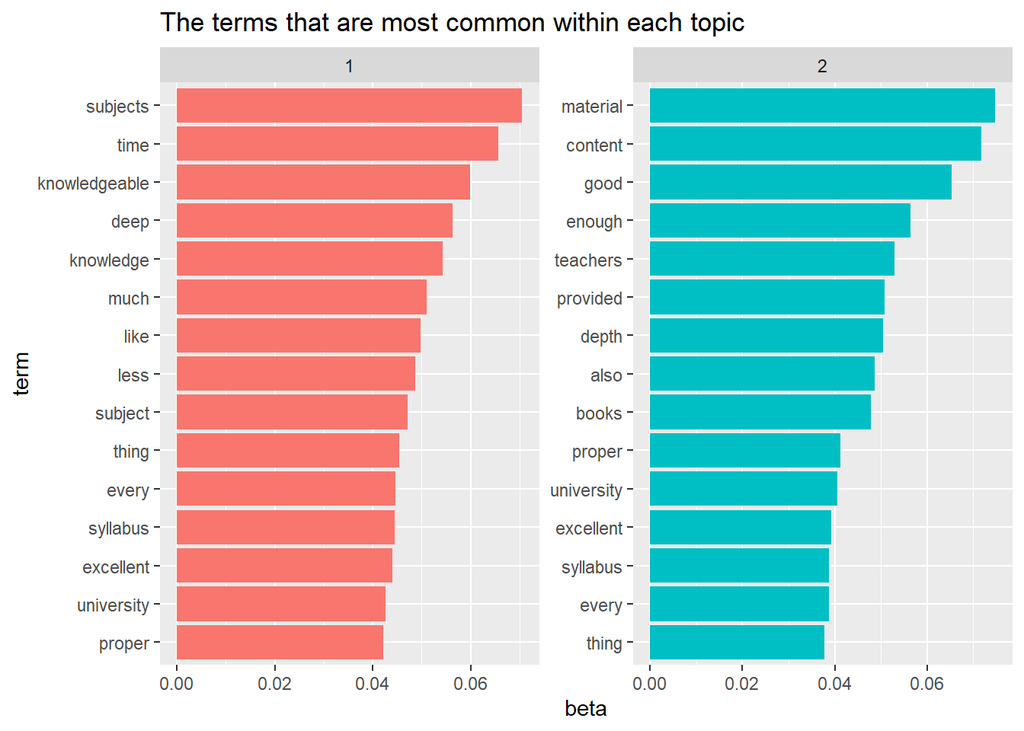

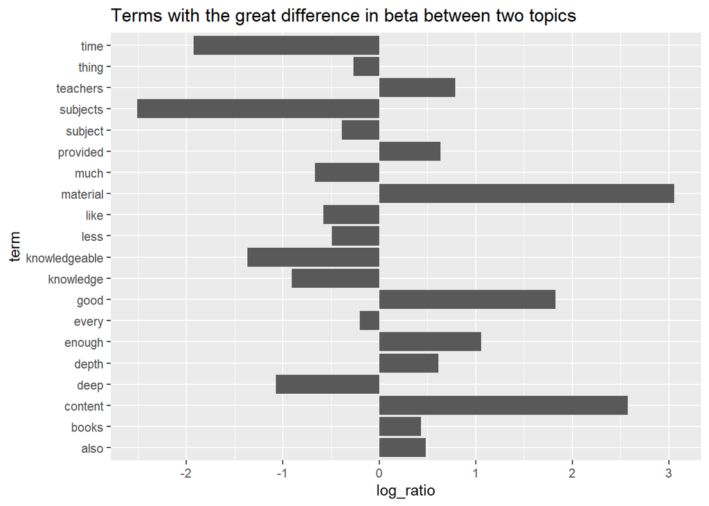

### Per quatre tòpics

Dividint les respostes dels alumnes en quatre grups:

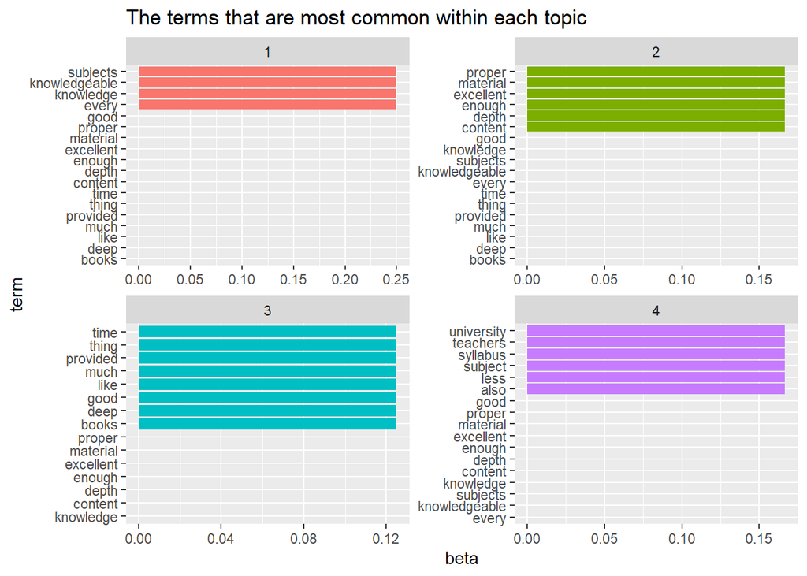

En el gràfic anterior es pot observar que el primer tema tracta els coneixements obtinguts a l’assignatura. El segon engloba els continguts i els materials del curs. El tercer està format sobretot per sentiments i opinions dels alumnes, mentre que el quart tema són la universitat i els professors.

Cal tenir en compte que hi ha un nombre limitat de respostes i aquestes són poc diverses, el que implica que l’anàlisi de temes no és del tot significatiu.